# ecoevonets slides

%=====================================================

%U Zurich BIO 365 Ecological Networks

%14 March -- 4 April, 2019

%---------------------------------

%Eco-evolutionary networks

%@Carlos Melian %Version March 14, 2019

%=====================================================

%---------------------------Intro--------------------------------------------------------------------------------

%Ecological and evolutionary processes are mixed together to drive population density and trait changes

%Most intuitive examples are biotic or abiotic factors driving trait and density changes within populations.

%Links between ecological and evolutonry processes have been incorporated in empirical and theoretical work for nearly a century.

%Yet, integrating rapid evolution or concurrent ecological and evolutionary time scales requires further research.

%In this intro we will discuss the importance of density- and frequency-dependent selection

%for understanding the connection between ecology and evolution

%----------------------------------------------------------------------------------------------------------------

%One of the most fundamental theorems in evolution to understand trait change driven by selection is the Price equation

%---------------------------------------------------------------------------------------------------------------------

%The Price equation has two terms, the first describing the mean phenotypic change due to selection

%and the second transmission bias -- In ecological terms, selecting factors can be many,

%abiotic like climate or habitat conditions, and biotic like predators, parasites or others. The transmission bias

%change can be due to change in the environment, mutations, or other forces not explicitly introduced in the equation

%---------------------------------------------------------------------------------------------------------------------

%It can be represented (using LateX symbols) as

$$\Delta \overline{\phi} = \frac{1}{\overline{w}} (cov(w,\phi) + E(w \delta))$$

%LateX example$$e^x=\sum_{i=0}^\infty \frac{1}{i!}x^i$$

%Further reading

%Gardner, A. (2008). The Price Equation. Current Biology, 18:PR198-R202.

%Queller, D. C. (2017). Fundamental Theorems of Evolution. The American Naturalist, 189:345-353.

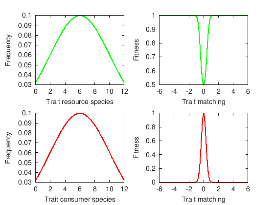

```matlab
%A simple example in octave of fitness dependent (w) of a trait value for one resource and one consumer,
%$\phi$, can be expressed as (Check octave free-software at $https://www.gnu.org/software/octave/$)

ecoevo1 %plots Figure 1
```

%... the resource fitness function producing the top right hand side plot above is

$$w(\phi) = \frac{1}{1 + e^{-\gamma(\phi_{R} - \overline{\phi}_{C})^2}}$$

```matlab
%which in octave is written as

%Fitness function for resources==================================================================

gamma = 5;%Strength of interaction between resource (trait value Zr) and consumer (trait value Zc)
for pB = 1:length(Zr);
    WB(pB,2) = 1/(1 + exp(-gamma*(Zr(1,pB) - mean(Zc))^2));
    WB(pB,1) = Zr(1,pB) - mean(Zc);
end
```

%and the consumer fitness function producing the bottom right hand side plot above is

$$w(\phi) = e^{-\gamma(\phi_{R} - \overline{\phi}_{C})^2}$$

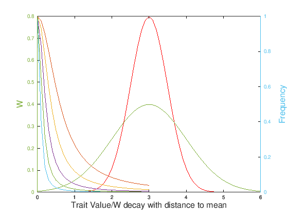

```matlab
%a more intuitive way of visualizing Figure 1 for the consumers is the following Figure 2
ecoevo1SI %plots Figure 2
```

```matlab
%on the left side of this plot we represent the decay in fitness when the trait value of a consumer
%deviates from the the mean trait value of the resource (maximum value with deviation equals to zero...).
%Trait distributions are the resource and consumer populations
```

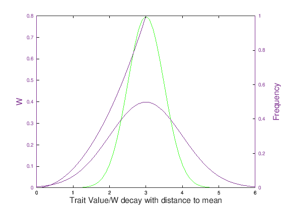

```matlab
ecoevo1SI2 %plots Figure 3
```

```matlab
%on the left side of this plot we represent the decay in fitness when the trait value of a resource
%deviates from the the mean trait value of the consumer (minimum value with deviation equals to zero...).
%Trait distributions are the resource and consumer populations
```

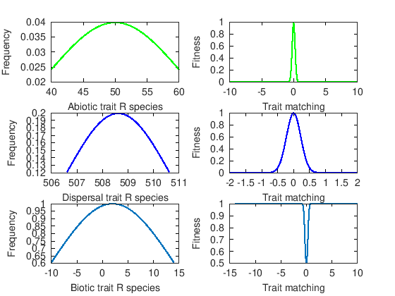

```matlab
ecoevoresource2 %plots Figure 4
```

```matlab
%we can think more broadly -- each individual can be formed by three traits,
%abiotic, dispersal and biotic and assuming independence among these traits
%we can plot the same figure as we did before only for the biotic trait
```

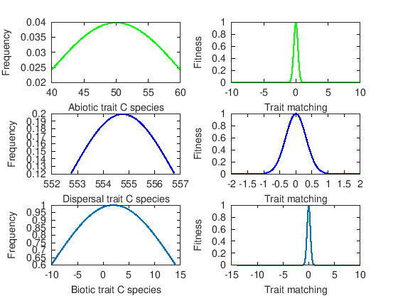

```matlab
ecoevoconsumer3 %plots Figure 5
```

```matlab
%and the same for the consumers. Notice the mean phenotype now increases fitness along the three traits
```

```matlab
%What about the dynamics? Until now we have only seen initial trait distrubitions
%and the fitness functions assotiated to them,...
%here we can start to explore the dynamics of trait distributions between resources and consumers
```

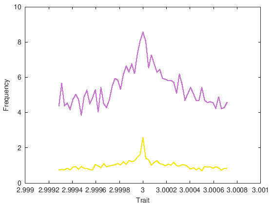

```matlab
ecoevo4mfd %plots Figure 6 -- the dynamics of positive frequency-dependent selection,
%only the common types both in the resorces and the consumers persist
%======download the required octave packages to visualize the animation======
```

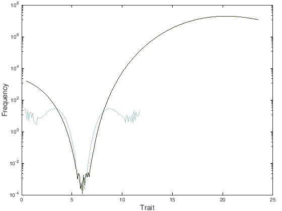

```matlab
ecoevo5fdsd%plots Figure 7 -- the dynamics of negative frequency-dependent selection,
%where the rare phenotypes both in  resources and consumers have advantage so they become common
%======download the required octave packages to visualize the animation======
```

```matlab
%Until now we have been dealing with one resource and one consumer with explicit trait variance,
%but most ecosystems are formed with many resources and consumers, predators, parasites, positive and negative interactions.
%Next section we will discuss eco-evolutionary networks accounting for many resources and consumers
```